# hw4-regression

### 載入ggplot2繪圖套件，以及匯入資料

```r
knitr::opts_chunk$set(echo = TRUE)
library(ggplot2)
dta <- read.table(file = "data/TIMSS2011TW.txt", header = TRUE)
```

### 檢視資料結構

```r
str(dta)
```

```
'data.frame':   4467 obs. of  13 variables:
 $ gender               : Factor w/ 2 levels "boy","girl": 2 2 2 2 2 2 2 2 2 2 ...
 $ math                 : num  729 776 718 607 658 ...
 $ math.interest        : num  8.93 13.47 9.6 13.47 8.27 ...
 $ math.evaluation      : num  9.34 9.34 10.35 10.35 8.21 ...
 $ math.input           : num  9.16 12.42 10.15 8.71 7.86 ...
 $ math.hours           : Factor w/ 3 levels "<= 45min",">= 3hours",..: 3 1 1 1 3 1 1 3 1 1 ...
 $ science              : num  683 663 667 575 650 ...
 $ science.interest     : num  7.65 7.65 9.42 9.42 9.04 ...
 $ science.evaluation   : num  9.16 6.53 11.09 7.6 8.23 ...
 $ science.input        : num  8.3 7.92 9.55 7.92 8.7 ...
 $ science.hours        : Factor w/ 3 levels "<= 45min",">= 3hours",..: 1 1 1 1 1 1 1 1 1 3 ...
 $ parental.education   : Factor w/ 5 levels "college","elementary school",..: 3 3 2 4 5 1 5 4 3 3 ...
 $ educational.resources: num  9.6 8.92 6.33 10.25 10.93 ...
```

### 各個欄位統計資料

```r
summary(dta)
```

```
  gender          math       math.interest    math.evaluation
 boy :2225   Min.   :166.4   Min.   : 5.037   Min.   : 3.412
 girl:2242   1st Qu.:556.0   1st Qu.: 7.912   1st Qu.: 7.274
             Median :629.9   Median : 8.930   Median : 8.207
             Mean   :618.1   Mean   : 9.079   Mean   : 8.357
             3rd Qu.:687.6   3rd Qu.: 9.965   3rd Qu.: 9.344
             Max.   :918.1   Max.   :13.465   Max.   :13.707
   math.input              math.hours      science      science.interest
 Min.   : 3.265   <= 45min      :1628   Min.   :178.8   Min.   : 4.513
 1st Qu.: 7.857   >= 3hours     : 803   1st Qu.:517.9   1st Qu.: 7.989
 Median : 8.584   45min - 3hours:2036   Median :577.5   Median : 9.039
 Mean   : 8.583                         Mean   :570.6   Mean   : 9.010
 3rd Qu.: 9.635                         3rd Qu.:627.2   3rd Qu.: 9.827
 Max.   :14.343                         Max.   :844.3   Max.   :12.944
 science.evaluation science.input           science.hours
 Min.   : 4.136     Min.   : 3.556   <= 45min      :2396
 1st Qu.: 7.601     1st Qu.: 7.524   >= 3hours     : 274
 Median : 8.540     Median : 8.700   45min - 3hours:1797
 Mean   : 8.556     Mean   : 8.613
 3rd Qu.: 9.479     3rd Qu.: 9.549
 Max.   :13.103     Max.   :13.833
          parental.education educational.resources
 college           : 672     Min.   : 4.323
 elementary school :  78     1st Qu.: 9.601
 high school       :2021     Median :10.254
 junior high school: 449     Mean   :10.486
 university above  :1247     3rd Qu.:11.649
                             Max.   :14.018
```

## 性別V.S.自然科學成績

### 男女成績的盒狀圖：可以看出兩者其實差不多

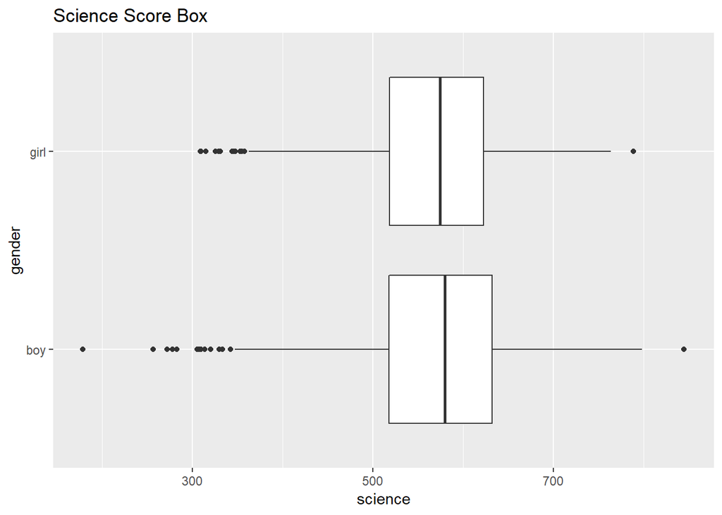

```r
ggplot(data = dta, aes(x = gender, y = science))+
 geom_boxplot() + coord_flip() +
 labs( y = 'science', x = 'gender',
       title = 'Science Score Box')
```

### 利用T檢定：p-value>0.05，代表性別影響不顯著，無法反駁，再繼續往下找

```r
t.test(science ~ gender, data = dta)
```

```
    Welch Two Sample t-test

data:  science by gender
t = 1.0131, df = 4393.2, p-value = 0.3111
alternative hypothesis: true difference in means is not equal to 0
95 percent confidence interval:
 -2.282085  7.163111
sample estimates:
 mean in group boy mean in group girl
          571.8732           569.4327
```

```r
t.test(science ~ gender, data = dta, var.equal = TRUE)
```

```
    Two Sample t-test

data:  science by gender
t = 1.0136, df = 4465, p-value = 0.3108
alternative hypothesis: true difference in means is not equal to 0
95 percent confidence interval:
 -2.279902  7.160929
sample estimates:
 mean in group boy mean in group girl
          571.8732           569.4327
```

## 學習興趣V.S.自然科學成績

### ☆★重點★☆：先把科學學習興趣的數值四捨五入，才能夠變為「質變數」

### 並且要將numeric格式轉為有順序的factor

### 各區段學習興趣（5～13）的盒狀圖，可以看出興趣越大，成績越高，代表兩者很可能有關連

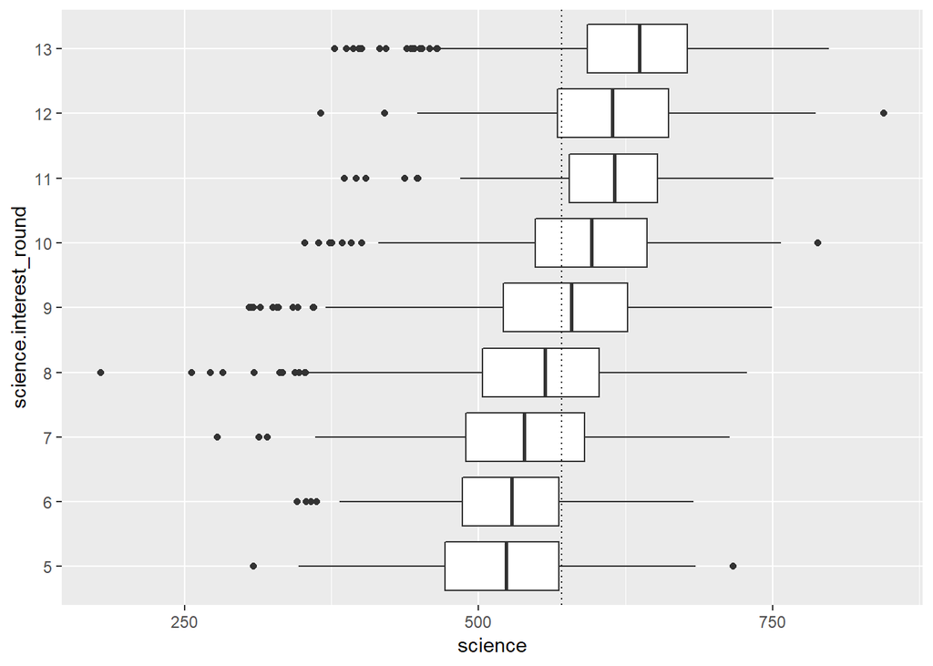

```r
library(Hmisc)
dta$science.interest_round<-round(dta$science.interest)
dta$science.interest_round<-factor(dta$science.interest_round,
                       levels = c(5:13))

ggplot(data = dta,
       aes(x = science.interest_round, y = science))+geom_boxplot() +
  scale_y_continuous(breaks = seq(250,750,by=250)) +
  geom_hline(yintercept = mean(dta$science) ,
             linetype = 'dotted') +
  coord_flip()
```

### anova：各區段學習興趣（5～13）

### p-value小於0.05，代表顯著，可以反駁

```r
anova(m1 <- lm(science ~ science.interest_round, data = dta))
```

```
Analysis of Variance Table

Response: science
                         Df   Sum Sq Mean Sq F value    Pr(>F)
science.interest_round    8  4209999  526250  94.967 < 2.2e-16 ***
Residuals              4458 24703447    5541
---
Signif. codes:  0 '***' 0.001 '**' 0.01 '*' 0.05 '.' 0.1 ' ' 1
```

## science.evaluation 價值評估V.S.自然科學成績：盒狀圖

### 一樣四捨五入再轉為factor

### 各區段價值評估（4～13）的盒狀圖，可以看出若是覺得科學有其學習的價值，成績就越高

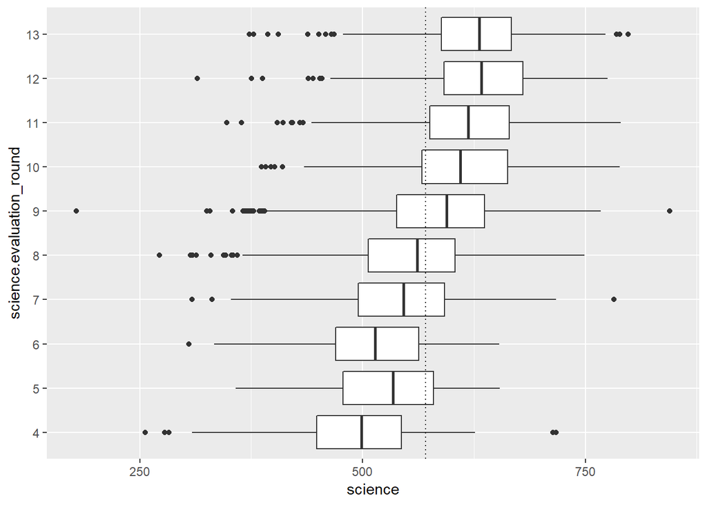

```r
dta$science.evaluation_round<-round(dta$science.evaluation)
dta$science.evaluation_round<-factor(dta$science.evaluation_round,
                       levels = c(4:13))

ggplot(data = dta,
       aes(x = science.evaluation_round, y = science))+geom_boxplot() +
  scale_y_continuous(breaks = seq(250,750,by=250)) +
  geom_hline(yintercept = mean(dta$science) ,
             linetype = 'dotted') +
  coord_flip()
```

## science.evaluation 價值評估V.S.自然科學成績：分布密度圖

### 評估價值的數值越高，分布的高峰愈往右邊成績高處

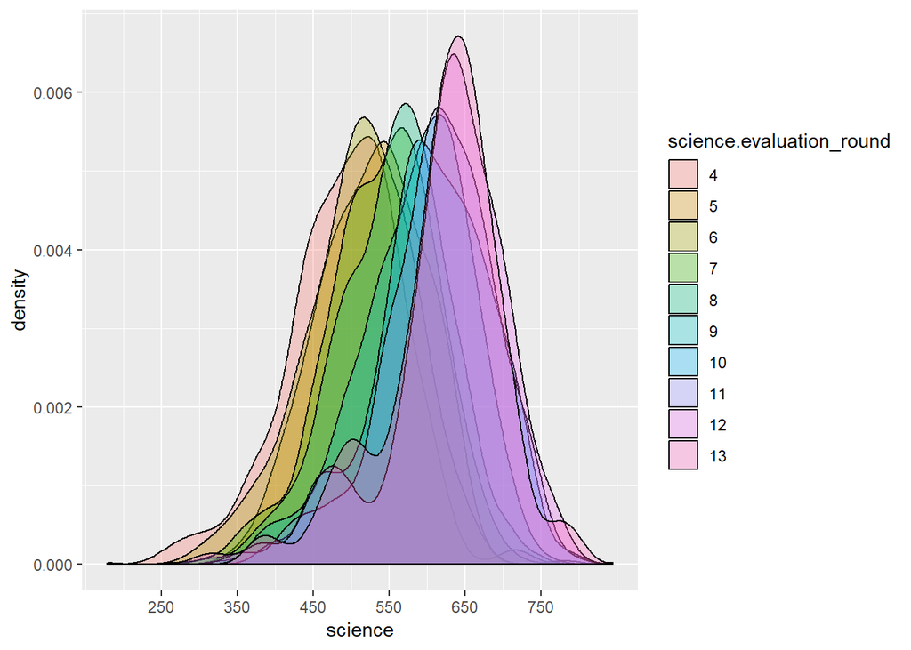

```r
ggplot(data = dta,
       aes(fill = science.evaluation_round, x = science))+geom_density(alpha=0.3) +
  scale_x_continuous(breaks = seq(250,750,by=100))
```

### anova：各區段價值評估（4～13）

### p-value小於0.05，代表顯著，可以反駁

```r
anova(m2 <- lm(science ~ science.evaluation_round, data = dta))
```

```
Analysis of Variance Table

Response: science
                           Df   Sum Sq Mean Sq F value    Pr(>F)
science.evaluation_round    9  4599851  511095   93.69 < 2.2e-16 ***
Residuals                4457 24313594    5455
---
Signif. codes:  0 '***' 0.001 '**' 0.01 '*' 0.05 '.' 0.1 ' ' 1
```

## science.input 投入程度V.S.自然科學成績

### 各區段投入程度（4～14）的點散佈圖，投入的努力越大，收穫越多，成績越高，但不太明顯

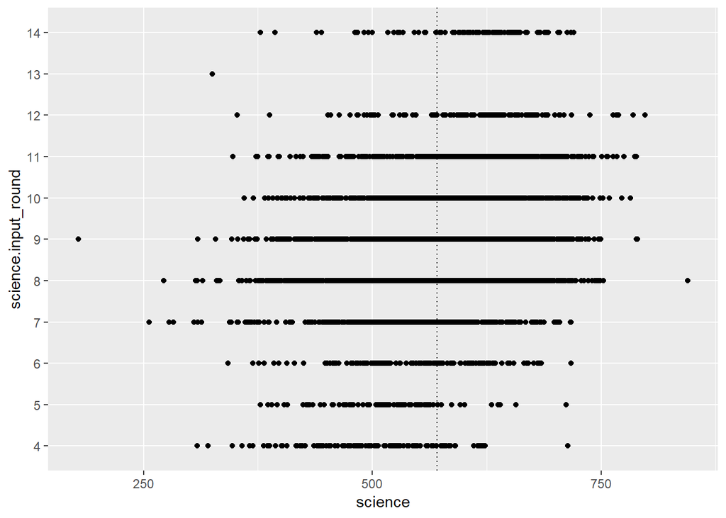

```r
dta$science.input_round<-round(dta$science.input)
dta$science.input_round<-factor(dta$science.input_round,
                       levels = c(4:14))

ggplot(data = dta,
       aes(x = science.input_round, y = science))+geom_point() +
  scale_y_continuous(breaks = seq(250,750,by=250)) +
  geom_hline(yintercept = mean(dta$science) ,
             linetype = 'dotted') +
  coord_flip()
```

### anova：各區段投入程度（4～14）

### p-value小於0.05，代表顯著，可以反駁

```r
anova(m3 <- lm(science ~ science.input_round, data = dta))
```

```
Analysis of Variance Table

Response: science
                      Df   Sum Sq Mean Sq F value    Pr(>F)
science.input_round   10  2663277  266328  45.209 < 2.2e-16 ***
Residuals           4456 26250169    5891
---
Signif. codes:  0 '***' 0.001 '**' 0.01 '*' 0.05 '.' 0.1 ' ' 1
```

### 三種時段的盒狀圖，結果看出三者的差異並不大

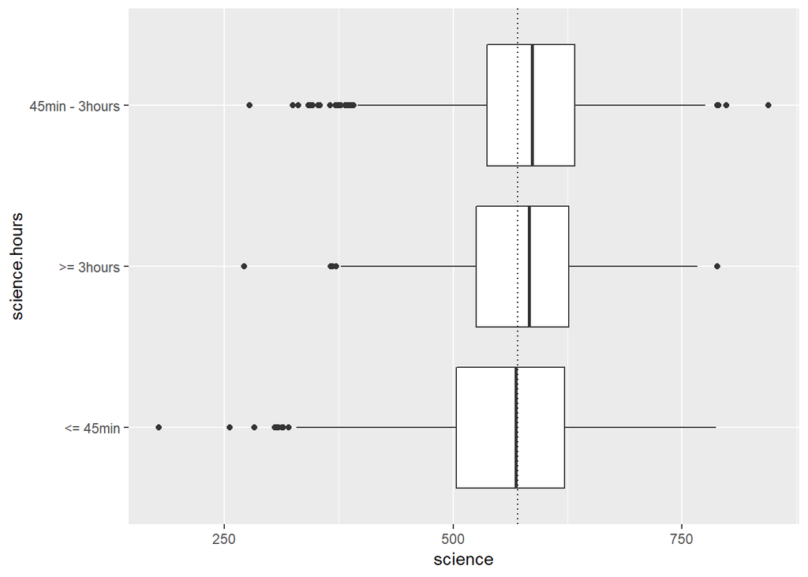

```r
ggplot(data = dta,
       aes(x = science.hours, y = science))+geom_boxplot() +
  scale_y_continuous(breaks = seq(250,750,by=250)) +
  geom_hline(yintercept = mean(dta$science) ,
             linetype = 'dotted') +
  coord_flip()
```

### anova：各區段投入時間（<45min；45min~3hr；>3hr）

### 但anova結果出來顯示，p-value小於0.05是顯著的，還得繼續分析下去

```r
anova(m4 <- lm(science ~ science.hours, data = dta))
```

```
Analysis of Variance Table

Response: science
                Df   Sum Sq Mean Sq F value    Pr(>F)
science.hours    2   482897  241449  37.911 < 2.2e-16 ***
Residuals     4464 28430548    6369
---
Signif. codes:  0 '***' 0.001 '**' 0.01 '*' 0.05 '.' 0.1 ' ' 1
```

### 學習興趣+價值評估+投入程度+投入時間的線性model -> m5

```r
m5 <- lm(science~+science.interest_round+science.evaluation_round+science.input_round+science.hours,data=dta)
```

### anova(m5)一起比較，可以看到「學習興趣」和「價值評估」的p-value是最顯著

```r
anova(m5)
```

```
Analysis of Variance Table

Response: science
                           Df   Sum Sq Mean Sq  F value    Pr(>F)
science.interest_round      8  4209999  526250 101.5864 < 2.2e-16 ***
science.evaluation_round    9  1284836  142760  27.5581 < 2.2e-16 ***
science.input_round        10   144823   14482   2.7956  0.001877 **
science.hours               2   288728  144364  27.8678 9.388e-13 ***
Residuals                4437 22985060    5180
---
Signif. codes:  0 '***' 0.001 '**' 0.01 '*' 0.05 '.' 0.1 ' ' 1
```

### 推測對自然科學的興趣與評斷自然科學的價值呈現正相關

### 可以看出對自然科學興趣大的人，覺得自然科學也有價值的人越聚集於多的地方，反之亦然

### 且幾乎都是正相關，700分以上之高分群大都是學習興趣9以上的學生

### 因此判定學習興趣及價值評估對自然科學成績的影響很大

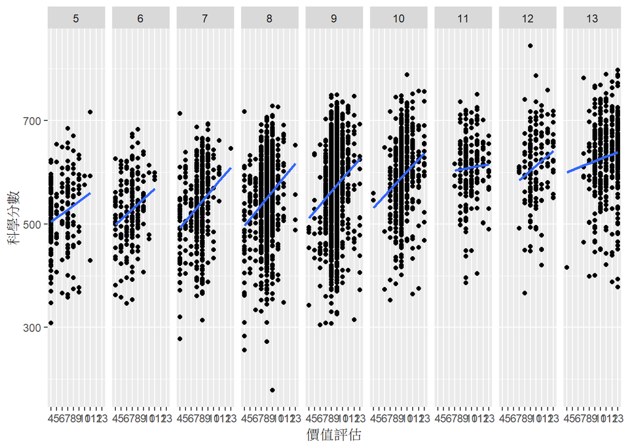

```r
ggplot(data = dta,
       aes(group = science.interest_round,
          y = science, x = science.evaluation_round)) +
  geom_point() +
  stat_smooth(method = 'lm', se = F) +
  stat_smooth(aes(group = science.interest_round,
          y = science, x = science.evaluation_round),
          method = 'lm', se = F) +
  facet_grid( . ~  science.interest_round) +
  labs(x = '價值評估', y = '科學分數')
```

### 載入畫圖套件

```r
library(coefplot)
```

### 迴歸變項的影響力

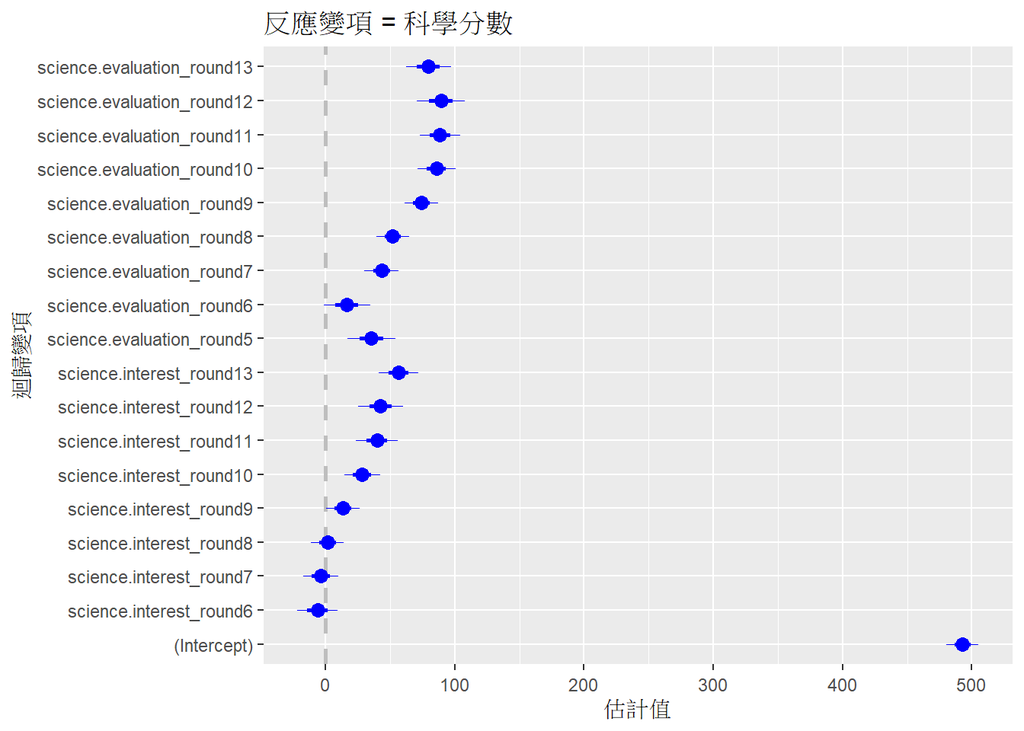

```r
coefplot( lm(science~+science.interest_round+science.evaluation_round,data=dta), xlab = '估計值', ylab = '迴歸變項', title = '反應變項 = 科學分數')
```

### 真實觀測值與預測值的疊合PART1：興趣+價值評估+投入程度+投入時間

### 不是非常吻合，再繼續找

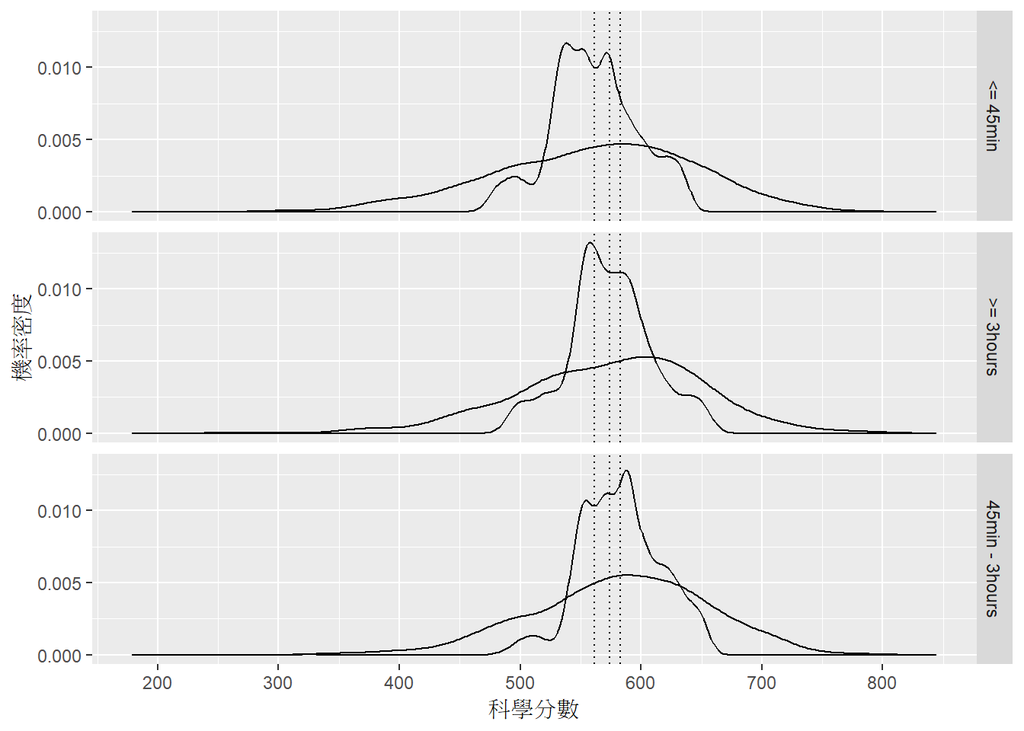

```r
fit_m5 <- data.frame(dta[, c(7,14,15,16, 11)], fitted = fitted(m5), resid = resid(m5),
                     infl = influence(m5)$hat )

ggplot(data = fit_m5, aes(x =science, group = science.hours )) +
 stat_density(geom = 'path', position = 'identity') +
 stat_density(geom = 'path', position = 'identity', aes(x = fitted)) +
 geom_vline(xintercept = c(with(dta, tapply(science,science.hours, mean))), linetype = 'dotted')+
 facet_grid(science.hours ~ .) +
 scale_x_continuous(breaks = seq(200, 900, by = 100))+
 labs(x = '科學分數', y = '機率密度')
```

### 真實觀測值與預測值的疊合PART2：興趣+價值評估+投入程度+投入時間+父母教育程度

### 還好，再繼續找

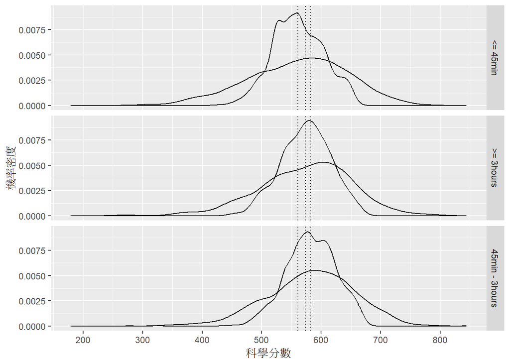

```r
m6 <- lm(science~+science.interest_round+science.evaluation_round+science.input_round+science.hours+parental.education,data=dta)

fit_m6 <- data.frame(dta[, c(7,14,15,16, 11,12)], fitted = fitted(m6), resid = resid(m6),
                     infl = influence(m6)$hat )

ggplot(data = fit_m6, aes(x =science, group =science.hours )) +
 stat_density(geom = 'path', position = 'identity') +
 stat_density(geom = 'path', position = 'identity', aes(x = fitted)) +
 geom_vline(xintercept = c(with(dta, tapply(science,science.hours, mean))), linetype = 'dotted')+
 facet_grid(science.hours ~ .) +
 scale_x_continuous(breaks = seq(200, 900, by = 100))+
 labs(x = '科學分數', y = '機率密度')
```

### 看一下依據價值評估的殘差Q-Q圖

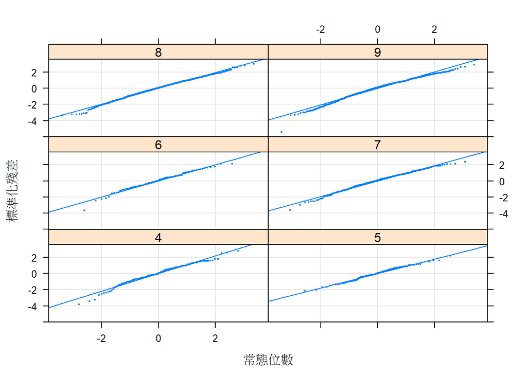

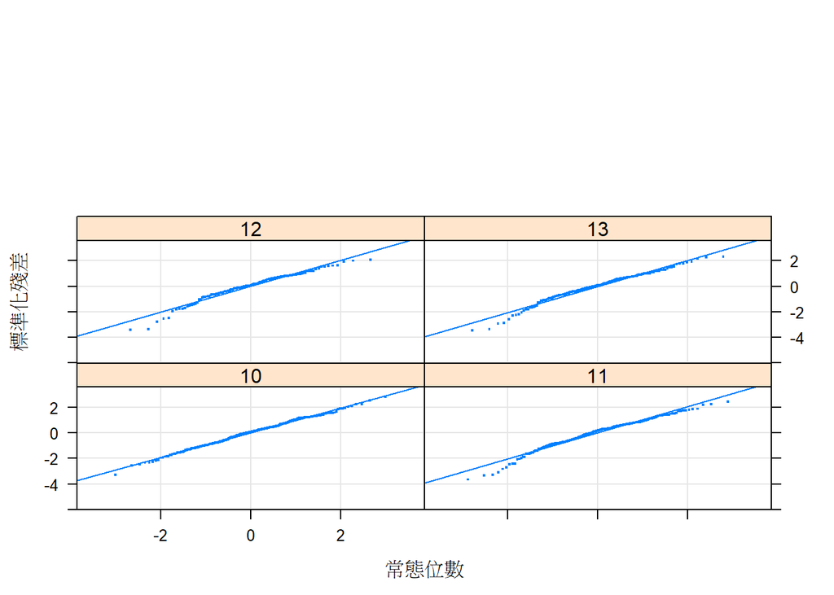

```r
require(lattice)
qqmath(~ scale(resid) | science.evaluation_round, data = fit_m6, type = c('p', 'g', 'r'),
       xlab = '常態位數', ylab = '標準化殘差', layout = c(2, 3),
       pch = '.', cex = 2)
```

### 真實觀測值與預測值的疊合PART3：興趣+價值評估+父母教育程度

### 拿掉投入程度+投入時間後，反而更不吻合ㄌ，再繼續…

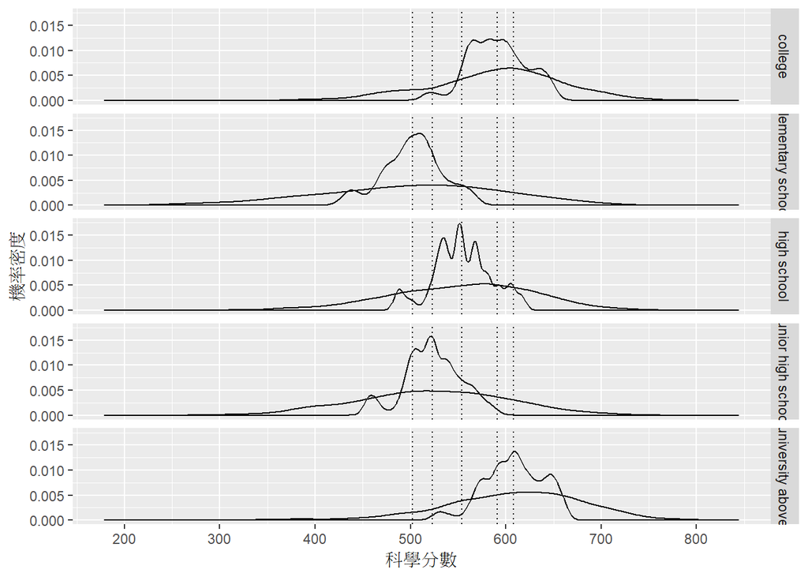

```r
m7<- lm(science~+science.interest_round+science.evaluation_round+parental.education,data=dta)
fit_m7 <- data.frame(dta[, c(7,14,15,12)], fitted = fitted(m7), resid = resid(m7),
                     infl = influence(m7)$hat )

ggplot(data = fit_m7, aes(x =science, group =parental.education )) +
 stat_density(geom = 'path', position = 'identity') +
 stat_density(geom = 'path', position = 'identity', aes(x = fitted)) +
 geom_vline(xintercept = c(with(dta, tapply(science,parental.education, mean))), linetype = 'dotted')+
 facet_grid(parental.education ~ .) +
 scale_x_continuous(breaks = seq(200, 900, by = 100))+
 labs(x = '科學分數', y = '機率密度')
```

### 真實觀測值與預測值的疊合PART4：興趣+價值評估+投入時間+父母教育程度

### 再加入投入時間後，變回跟PART2的結果差不多，再繼續…

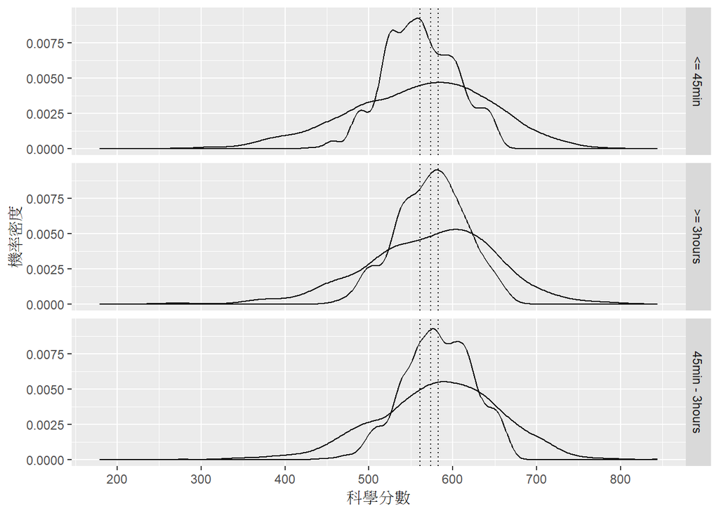

```r
m8<- lm(science~+science.interest_round+science.evaluation_round+science.hours+parental.education,data=dta)
fit_m8 <- data.frame(dta[, c(7,14,15,12,11)], fitted = fitted(m8), resid = resid(m8),
                     infl = influence(m8)$hat )

ggplot(data = fit_m8, aes(x =science, group =science.hours )) +
 stat_density(geom = 'path', position = 'identity') +
 stat_density(geom = 'path', position = 'identity', aes(x = fitted)) +
 geom_vline(xintercept = c(with(dta, tapply(science,science.hours, mean))), linetype = 'dotted')+
 facet_grid(science.hours ~ .) +
 scale_x_continuous(breaks = seq(200, 900, by = 100))+
 labs(x = '科學分數', y = '機率密度')
```

### 真實觀測值與預測值的疊合PART5：興趣+價值評估+投入時間+父母教育程度+投入資源

### 加入投入資源看看，一樣先四捨五入，再轉為factor

### 由結果可知，這是最吻合的，所以最後可以推斷，

### 興趣+價值評估+投入時間+父母教育程度+投入資源

### 是五項影響學生自然科學成績的最主要的因子。

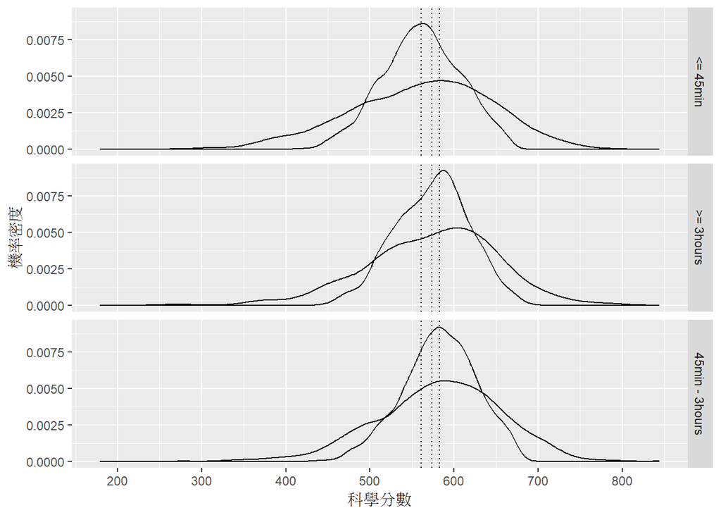

```r
dta$educational.resources_round<-round(dta$educational.resources)
dta$educational.resources_round<-factor(dta$educational.resources_round,
                       levels = c(4:14))
m9<- lm(science~+science.interest_round+science.evaluation_round+science.hours+parental.education+educational.resources_round,data=dta)
fit_m9 <- data.frame(dta[, c(7,14,15,12,11,17)], fitted = fitted(m9), resid = resid(m9),
                     infl = influence(m9)$hat )

ggplot(data = fit_m9, aes(x =science, group =science.hours )) +
 stat_density(geom = 'path', position = 'identity') +
 stat_density(geom = 'path', position = 'identity', aes(x = fitted)) +
 geom_vline(xintercept = c(with(dta, tapply(science,science.hours, mean))), linetype = 'dotted')+
 facet_grid(science.hours ~ .) +
 scale_x_continuous(breaks = seq(200, 900, by = 100))+
 labs(x = '科學分數', y = '機率密度')
```